# AI-Driven Customer Segmentation and Predictive Modeling in Marketing Analytics

## Project Objectives

Based on the project brief, the primary goals of this analysis are:

1. *Objective 1: Segmentation:* Use AI clustering techniques (specifically K-Means) to effectively segment mall customers into distinct groups based on their spending behavior and annual income.
2. *Objective 2: Analysis:* Analyze the characteristics of each identified segment to create clear customer profiles (e.g., "High-Value," "Frugal," "Impulse Buyers").
3. *Objective 3: Prediction:* Build a supervised learning model (Decision Tree Classifier) to accurately predict which segment a new, unclassified customer will belong to.
4. *Objective 4: Actionable Insights:* Generate tailored and data-backed marketing strategies for each customer group, providing a clear pathway for application in retail and e-commerce.

### Importing Libraries

```python
import numpy as np
import pandas as pd
import matplotlib.pyplot as plt
import seaborn as sns
from sklearn.cluster import KMeans
```

### Data Collection & Analysis

```python
# loading the data from csv file to a Pandas DataFrame
customer_data = pd.read_csv(r"C:\Users\sneha\Downloads\Mall_Customers.csv")
```

```python
# first 5 rows in the dataframe
customer_data.head()
```

|  | CustomerID | Gender | Age | Annual Income (k$) | Spending Score (1-100) |
| --- | --- | --- | --- | --- | --- |
| 0 | 1 | Male | 19 | 15 | 39 |
| 1 | 2 | Male | 21 | 15 | 81 |
| 2 | 3 | Female | 20 | 16 | 6 |
| 3 | 4 | Female | 23 | 16 | 77 |
| 4 | 5 | Female | 31 | 17 | 40 |

```python
# finding the number of rows and columns
customer_data.shape
```

```
(200, 5)
```

```python
# getting some informations about the dataset
customer_data.info()
```

```
<class 'pandas.core.frame.DataFrame'>
RangeIndex: 200 entries, 0 to 199
Data columns (total 5 columns):
 #   Column                  Non-Null Count  Dtype
---  ------                  --------------  -----
 0   CustomerID              200 non-null    int64
 1   Gender                  200 non-null    object
 2   Age                     200 non-null    int64
 3   Annual Income (k$)      200 non-null    int64
 4   Spending Score (1-100)  200 non-null    int64
dtypes: int64(4), object(1)
memory usage: 7.9+ KB
```

```python
# checking for missing values
customer_data.isnull().sum()
```

```
CustomerID                0
Gender                    0
Age                       0
Annual Income (k$)        0
Spending Score (1-100)    0
dtype: int64
```

### Pair Plot

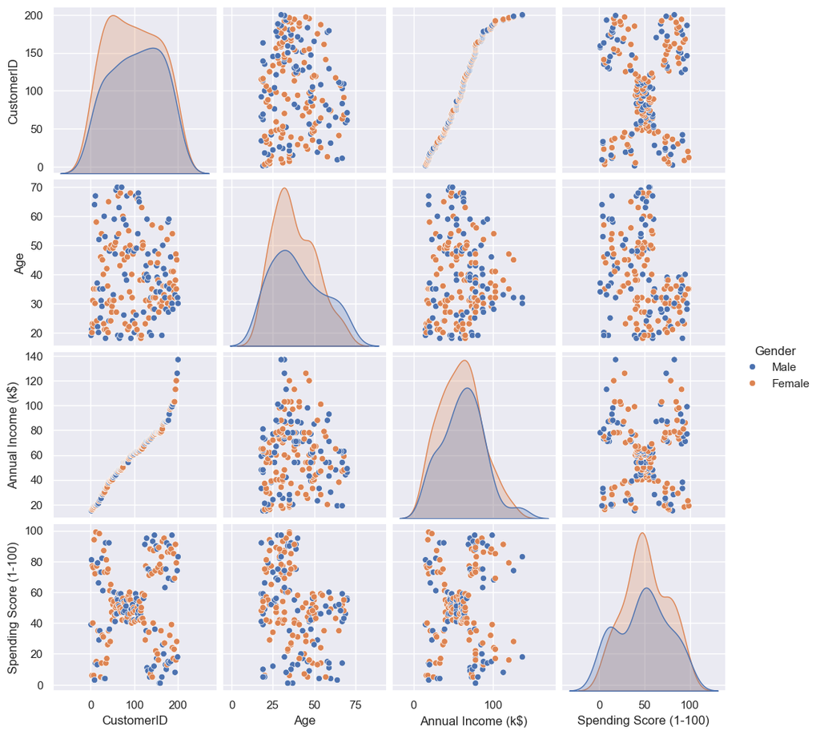

```python
# Analyze correlation between variables
sns.pairplot(customer_data, hue='Gender')
plt.show()
```

## Correlation Heatmap

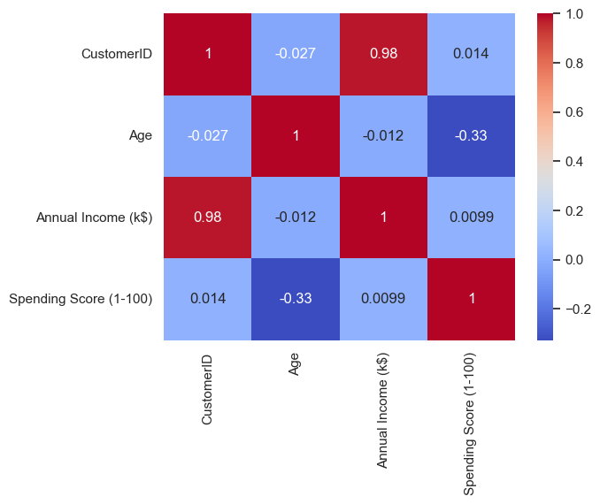

```python
corr = customer_data.select_dtypes(include='number').corr()
sns.heatmap(corr, annot=True, cmap='coolwarm')
plt.show()
```

## Insights from Correlation Heatmap

- *Age vs Spending Score (-0.33):* Older customers tend to spend less; younger customers show higher spending scores.
- *Income vs Spending Score (≈0):* No clear link between income and spending habits → income alone is not a good predictor.
- *CustomerID Correlation:* The strong link with income is artificial (data sorted), not a meaningful relationship.

## Histogram for Age and its count

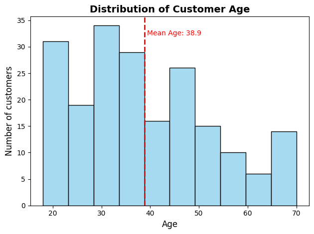

```python
# Histogram for Age vs Count
sns.histplot(customer_data['Age'], bins=10, color='skyblue', edgecolor='black')
plt.title('Distribution of Customer Age', fontsize=14, fontweight='bold')
plt.xlabel('Age', fontsize=12)
plt.ylabel('Number of customers', fontsize=12)

# Add vertical line for average age
mean_age = customer_data['Age'].mean()
plt.axvline(mean_age, color='red', linestyle='--', linewidth=2)
plt.text(mean_age+0.5, plt.ylim()[1]*0.9, f'Mean Age: {mean_age:.1f}', color='red', fontsize=10)

plt.tight_layout()
plt.show()
```

## Insights from Age Histogram

- Most common age group is *30–35 years*, making up the largest customer segment.
- A significant number of customers are in their *20s (20–30 years)*, showing strong appeal to younger adults.
- The customer base is mainly within the *20–50 age range*, a key target for marketing strategies.

## Histogram for Annual Income and Count

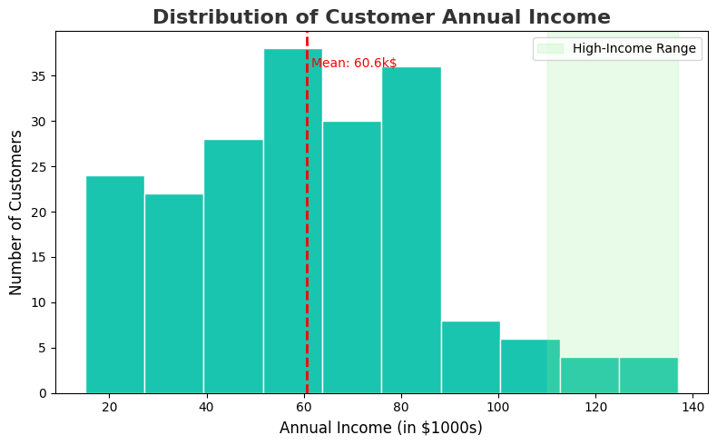

```python
# Enhanced Histogram for Annual Income vs Count
plt.figure(figsize=(8,5))
sns.histplot(
    data=customer_data,
    x='Annual Income (k$)',
    bins=10,
    color='#00BFA5',         # teal color
    edgecolor='white',
    alpha=0.9
)

# Add title and labels
plt.title('Distribution of Customer Annual Income', fontsize=16, fontweight='bold', color='#333333')
plt.xlabel('Annual Income (in $1000s)', fontsize=12)
plt.ylabel('Number of Customers', fontsize=12)

# Add mean income line
mean_income = customer_data['Annual Income (k$)'].mean()
plt.axvline(mean_income, color='red', linestyle='--', linewidth=2)
plt.text(mean_income+1, plt.ylim()[1]*0.9, f'Mean: {mean_income:.1f}k$', color='red', fontsize=10)

# Highlight high-income end visually
plt.axvspan(110, max(customer_data['Annual Income (k$)']), color='lightgreen', alpha=0.2, label='High-Income Range')

plt.legend(loc='upper right', fontsize=10)
plt.tight_layout()
plt.show()
```

## Histogram for Spending score and Count

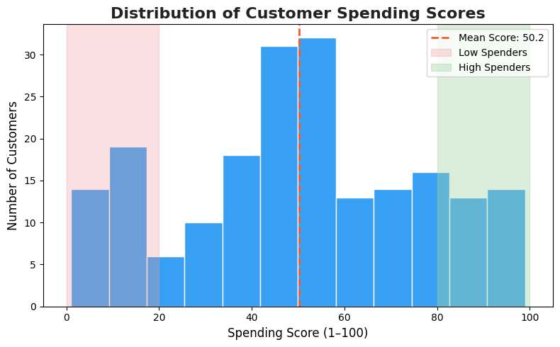

```python
# Histogram for Spending Score Distribution
plt.figure(figsize=(8,5))
sns.histplot(
    data=customer_data,
    x='Spending Score (1-100)',
    bins=12,
    color='#2196F3',       # elegant blue tone
    edgecolor='white',
    alpha=0.9
)

# Add title and labels
plt.title('Distribution of Customer Spending Scores', fontsize=16, fontweight='bold', color='#222222')
plt.xlabel('Spending Score (1–100)', fontsize=12)
plt.ylabel('Number of Customers', fontsize=12)

# Add mean spending line
mean_spend = customer_data['Spending Score (1-100)'].mean()
plt.axvline(mean_spend, color='#FF5722', linestyle='--', linewidth=2, label=f'Mean Score: {mean_spend:.1f}')

# Highlight low and high spender ranges
plt.axvspan(0, 20, color='#EF9A9A', alpha=0.3, label='Low Spenders')
plt.axvspan(80, 100, color='#A5D6A7', alpha=0.4, label='High Spenders')

# Add legend and layout adjustments
plt.legend(loc='upper right', fontsize=10)
plt.tight_layout()
plt.show()
```

## Insights from Spending Score Histogram

- Majority of customers are *average spenders (40–60 range)*.
- A strong *high-spending group (>70)* exists, ideal for premium targeting.
- A notable *low-spending group (0–20)* reflects price-sensitive or infrequent shoppers.
- The *multi-peaked distribution* confirms distinct customer segments, supporting the need for clustering-based strategies.

#### Choosing the Annual Income Column & Spending Score column

```python
X = customer_data.iloc[:,[3,4]].values
```

```python
print(X)
```

[output not shown]

[output cut: 145 more lines]

[output not shown]

#### WCSS -> Within Clusters Sum of Squares

```python
# finding wcss value for different number of clusters

wcss = []

for i in range(1,11):
  kmeans = KMeans(n_clusters=i, init='k-means++', random_state=42)
  kmeans.fit(X)

  wcss.append(kmeans.inertia_)
```

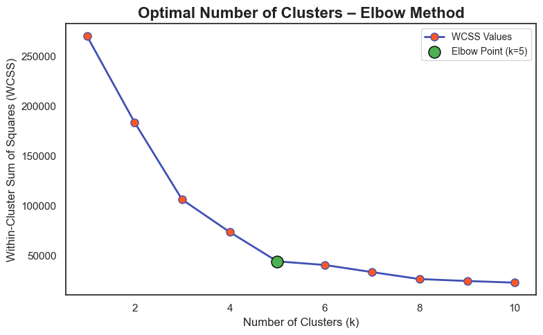

```python
# Elbow Point Graph
plt.figure(figsize=(8,5))
sns.set(style="white")

# Plot line with markers
plt.plot(
    range(1, 11),
    wcss,
    marker='o',
    linestyle='-',
    color='#3F51B5',
    linewidth=2,
    markersize=8,
    markerfacecolor='#FF5722',
    label='WCSS Values'
)

# Highlight the elbow point (5 clusters)
plt.scatter(5, wcss[4], color='#4CAF50', s=150, edgecolor='black', label='Elbow Point (k=5)', zorder=5)

# Titles and labels
plt.title('Optimal Number of Clusters – Elbow Method', fontsize=16, fontweight='bold', color='#222222')
plt.xlabel('Number of Clusters (k)', fontsize=12)
plt.ylabel('Within-Cluster Sum of Squares (WCSS)', fontsize=12)

plt.legend(fontsize=10)
plt.tight_layout()
plt.show()
```

## Elbow Point Graph

### *Explanation*

- Shows the relationship between *number of clusters (K)* and *WCSS*.
- WCSS decreases as K increases, but after a point, the drop slows down.
- The point where the curve bends (the "elbow") gives the *optimal number of clusters*.

### *Insights*

- The elbow appears at *K = 5*.
- Hence, *5 clusters* best fit the data.
- Adding more clusters doesn’t improve results much after this point.

#### Optimum Number of Clusters = 5

#### Training the k-Means Clustering Model

```python
kmeans = KMeans(n_clusters=5, init='k-means++', random_state=0)

# return a label for each data point based on their cluster
Y = kmeans.fit_predict(X)

print(Y)
```

```
[3 4 3 4 3 4 3 4 3 4 3 4 3 4 3 4 3 4 3 4 3 4 3 4 3 4 3 4 3 4 3 4 3 4 3 4 3
 4 3 4 3 4 3 0 3 4 0 0 0 0 0 0 0 0 0 0 0 0 0 0 0 0 0 0 0 0 0 0 0 0 0 0 0 0
 0 0 0 0 0 0 0 0 0 0 0 0 0 0 0 0 0 0 0 0 0 0 0 0 0 0 0 0 0 0 0 0 0 0 0 0 0
 0 0 0 0 0 0 0 0 0 0 0 0 1 2 1 0 1 2 1 2 1 0 1 2 1 2 1 2 1 2 1 0 1 2 1 2 1
 2 1 2 1 2 1 2 1 2 1 2 1 2 1 2 1 2 1 2 1 2 1 2 1 2 1 2 1 2 1 2 1 2 1 2 1 2
 1 2 1 2 1 2 1 2 1 2 1 2 1 2 1]
```

#### 5 Clusters - 0, 1, 2, 3, 4

#### Visualizing all the Clusters

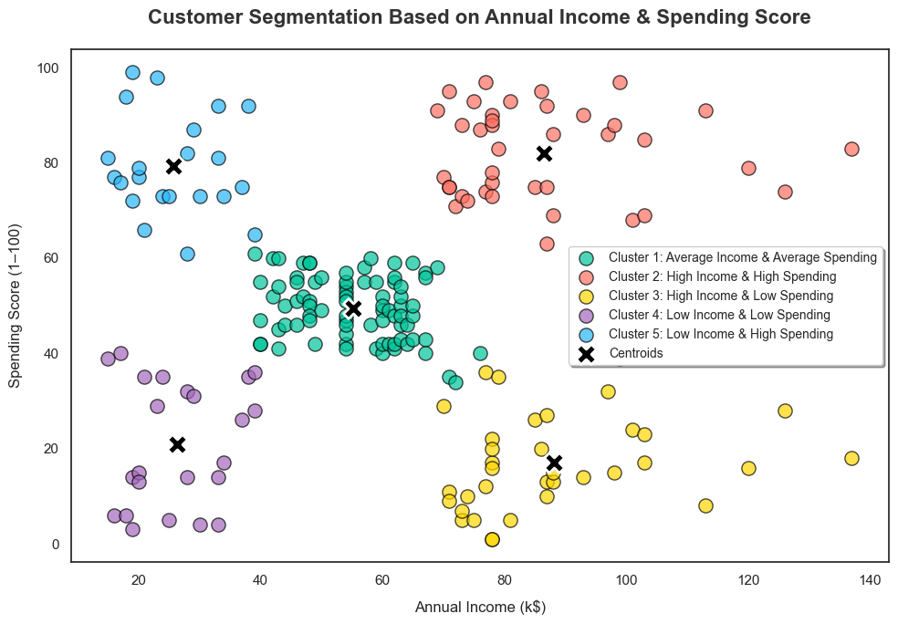

```python
plt.figure(figsize=(10, 7))
sns.set_style("white")

# cluster visualization
plt.scatter(X[Y == 0, 0], X[Y == 0, 1], s=120, c='#00C49A', label='Cluster 1: Average Income & Average Spending', alpha=0.7, edgecolors='black')
plt.scatter(X[Y == 1, 0], X[Y == 1, 1], s=120, c='#FF6F61', label='Cluster 2: High Income & High Spending', alpha=0.7, edgecolors='black')
plt.scatter(X[Y == 2, 0], X[Y == 2, 1], s=120, c='#FFD700', label='Cluster 3: High Income & Low Spending', alpha=0.7, edgecolors='black')
plt.scatter(X[Y == 3, 0], X[Y == 3, 1], s=120, c='#A569BD', label='Cluster 4: Low Income & Low Spending', alpha=0.7, edgecolors='black')
plt.scatter(X[Y == 4, 0], X[Y == 4, 1], s=120, c='#29B6F6', label='Cluster 5: Low Income & High Spending', alpha=0.7, edgecolors='black')

# Highlight centroids
plt.scatter(kmeans.cluster_centers_[:, 0],
            kmeans.cluster_centers_[:, 1],
            s=250,
            c='black',
            marker='X',
            edgecolor='white',
            linewidth=2,
            label='Centroids')

# Titles and labels
plt.title('Customer Segmentation Based on Annual Income & Spending Score',
          fontsize=16,
          fontweight='bold',
          color='#333333',
          pad=20)
plt.xlabel('Annual Income (k$)', fontsize=12, labelpad=10)
plt.ylabel('Spending Score (1–100)', fontsize=12, labelpad=10)

# Add legend
plt.legend(fontsize=10, loc='best', frameon=True, shadow=True, fancybox=True)
plt.tight_layout()
plt.show()
```

### Customer Cluster Insights

1. *Cluster 1 (Green):* Customers with average income and average spending. Represent the mall’s balanced middle segment.
2. *Cluster 2 (Red):* High income, high spending customers — the premium target group for loyalty programs and exclusive offers.
3. *Cluster 3 (Yellow):* High income, low spending group — potential customers who can be encouraged through luxury or value-driven promotions.
4. *Cluster 4 (Purple):* Low income, low spending group — budget-conscious customers; promotions and discounts may attract more spending.
5. *Cluster 5 (Blue):* Low income, high spending customers — younger, impulse-driven buyers who respond well to trendy or limited-time offers.

```python
# Import necessary libraries
import pandas as pd
from sklearn.cluster import KMeans
from sklearn.preprocessing import LabelEncoder, StandardScaler
import matplotlib.pyplot as plt

# Create a copy to work with
customer_data_clustered = customer_data.copy()

# Step 1: Handle Categorical Data (Gender)
# Use LabelEncoder to convert 'Gender' to a numerical value
le = LabelEncoder()
customer_data_clustered['Gender'] = le.fit_transform(customer_data_clustered['Gender'])

# Step 2: Select features for clustering
X_cluster = customer_data_clustered[['Annual Income (k$)', 'Spending Score (1-100)']]

# Step 3: Train K-Means model to get cluster labels
# We use n_clusters=5 based on the Elbow Method you already performed
kmeans = KMeans(n_clusters=5, init='k-means++', random_state=0)
Y_cluster_labels = kmeans.fit_predict(X_cluster)

# Add the cluster labels back to the DataFrame
customer_data_clustered['Cluster_ID'] = Y_cluster_labels

print("DataFrame with Cluster_ID:")
print(customer_data_clustered.head())
```

```
DataFrame with Cluster_ID:
   CustomerID  Gender  Age  Annual Income (k$)  Spending Score (1-100)  \
0           1       1   19                  15                      39
1           2       1   21                  15                      81
2           3       0   20                  16                       6
3           4       0   23                  16                      77
4           5       0   31                  17                      40

   Cluster_ID
0           3
1           4
2           3
3           4
4           3
```

```
Model Accuracy: 0.975

Classification Report:
               precision    recall  f1-score   support

           0       0.95      1.00      0.97        18
           1       1.00      1.00      1.00         5
           2       1.00      0.91      0.95        11
           3       1.00      1.00      1.00         3
           4       1.00      1.00      1.00         3

    accuracy                           0.97        40
   macro avg       0.99      0.98      0.99        40
weighted avg       0.98      0.97      0.97        40
```

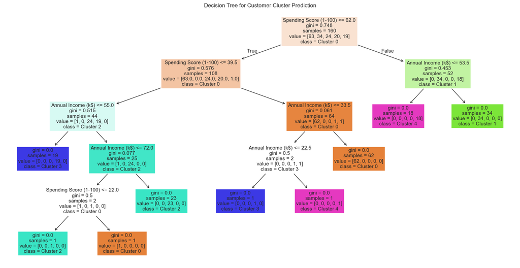

```
New customer with Age 30, Income 75k, and Spending Score 80 is predicted to belong to Cluster: 1
```

```python
# Import necessary libraries for the classifier
from sklearn.tree import DecisionTreeClassifier, plot_tree
from sklearn.model_selection import train_test_split
from sklearn.metrics import accuracy_score, classification_report
import matplotlib.pyplot as plt
import pandas as pd

# Define the features (X) you want to use for prediction and the target (y)
# We will use Age, Income, and Spending Score to predict the cluster.
# Note: 'Gender' is not included here because you already used it for clustering.
# However, you could add it to see how it affects the prediction.
features = ['Age', 'Annual Income (k$)', 'Spending Score (1-100)']
X = customer_data_clustered[features]
y = customer_data_clustered['Cluster_ID']

# Split the data into training and testing sets (80% for training, 20% for testing)
X_train, X_test, y_train, y_test = train_test_split(X, y, test_size=0.2, random_state=42)

# Initialize and train the Decision Tree model
model = DecisionTreeClassifier(random_state=42)
model.fit(X_train, y_train)

# Make predictions on the unseen test set
y_pred = model.predict(X_test)

# Evaluate the model's performance
print("\nModel Accuracy:", accuracy_score(y_test, y_pred))
print("\nClassification Report:\n", classification_report(y_test, y_pred))

# Visualize the trained Decision Tree
# This is a great way to show how the model makes decisions.
plt.figure(figsize=(20, 10))
plot_tree(model, filled=True, feature_names=features, class_names=[f'Cluster {i}' for i in range(5)])
plt.title("Decision Tree for Customer Cluster Prediction")
plt.show()

# Example: Predict the cluster for a new, unseen customer
new_customer_data = pd.DataFrame([[30, 75, 80]], columns=features)
predicted_cluster = model.predict(new_customer_data)
print(f"\nNew customer with Age 30, Income 75k, and Spending Score 80 is predicted to belong to Cluster: {predicted_cluster[0]}")
```

#### Key Customer Rules

```python
# Example 1: Predict the cluster for a new, unseen customer
new_customer_data = pd.DataFrame([[30, 75, 80]], columns=features)
predicted_cluster = model.predict(new_customer_data)
print(f"\nNew customer with Age 30, Income 75k, and Spending Score 80 is predicted to belong to Cluster: {predicted_cluster[0]}")
```

```
New customer with Age 30, Income 75k, and Spending Score 80 is predicted to belong to Cluster: 1
```

```python
# Example 2: Predict another unseen customer
new_customer_data2 = pd.DataFrame([[45, 40, 25]], columns=features)
predicted_cluster2 = model.predict(new_customer_data2)
print(f"New customer with Age 45, Income 40k, and Spending Score 25 is predicted to belong to Cluster: {predicted_cluster2[0]}")
```

```
New customer with Age 45, Income 40k, and Spending Score 25 is predicted to belong to Cluster: 3
```

# Customer Segmentation Project - Final Summary & Suggestions

## Project Overview

The objective of this project was to analyze mall customers and group them based on *Annual Income* and *Spending Score* using *K-Means Clustering* and then train a *Decision Tree Classifier* to predict customer clusters for new entries. By understanding customer behavior, businesses can design targeted marketing strategies and improve customer engagement.

## Key Insights

### 2. Correlations

- *Age vs Spending Score:* Moderate negative correlation (-0.33) → younger customers spend more.
- *Income vs Spending Score:* Near zero correlation → income alone doesn’t determine spending habits.
- *Cluster Formation:* Combining Income and Spending Score is essential for meaningful segmentation.

## 3. K-Means Clusters (K = 5)

[output not shown]

## 4. Decision Tree Classifier

- Trained to predict clusters for *new customers* based on Age, Income, and Spending Score.
- Achieved *97.5% accuracy*, making it highly reliable for classifying unseen customers.
- Example Predictions:
  - Age 30, Income 75k, Spending Score 80 → *Cluster 1* → Premium high-value customer.
  - Age 45, Income 40k, Spending Score 25 → *Cluster 3* → Budget-conscious customer.

## 5. Practical Applications & Suggestions

Based on the cluster insights, businesses can design *customized email campaigns and offers*:

- *Cluster 0 (Moderate buyers):* Send newsletters, seasonal offers, and loyalty rewards.
- *Cluster 1 (Premium customers):* Send VIP invitations, exclusive discounts, early access to new products, and personalized high-value promotions.
- *Cluster 2 (Potential high spenders):* Encourage higher spending through bundled deals, discounts, or personalized recommendations.
- *Cluster 3 (Budget-conscious):* Focus on cost-effective promotions, value-for-money offers, or informational content.
- *Cluster 4 (Impulsive buyers):* Flash sales, limited-time offers, and loyalty points programs to retain engagement.

*Additional Suggestion:*

- We can also create an *interactive app* based on this Decision Tree model, where entering a new customer’s details instantly predicts their cluster.
- Such an app would allow the marketing team to *automatically classify customers* and *send personalized emails/offers* according to their predicted cluster, improving targeting and customer satisfaction.

## 6. Conclusion

- The project successfully *segmented customers* and provided actionable insights for each cluster.
- The Decision Tree ensures *predictive capability for new customers*, making the segmentation process scalable.
- Businesses can leverage these insights for *personalized marketing, targeted campaigns, and customer retention strategies*.